# Nest orientation analysis in Tree Swallows

Jared Gladbach, Kamau Braxton-Hall, Mackenzie Alderson, Camilo Alfonso, Miguel Cesar Moreno-Palacios, Ignacio Moore

2026-07-17

# Overview

This project investigates the relationship between nest box entrance orientaion and nest-box occupancy, clutch size, and hatching success in the Tree swallows. All analyses were conducted in R Core Team 2024 and the code included data preparation, model fitting, diagnostic test, and figure graphing.

# ANALYSIS 1: Seasonal occupancy patterns

## Objective

This analysis tests whether nest-box occupancy changes over the breeding season and whether this temporal pattern differs among nest entrance orientations.

Because preliminary linear analyses did not detect an effect of day of the year on nest-box occupancy, generalized additive models (GAMs) were used to evaluate potential non-linear relationships between occupancy and time.

The following steps prepare the dataset for analysis: 1.Convert variables to factors. 2.Generate date and day-of-year variables using **lubridate**. 3.Restrict the dataset to the main breeding period (15 April–1 June 2023). 4.Convert nest-box status into a binary occupancy variable.

```r
tres <-read.csv("../Data/tres.csv")

tres$orientation <- as.factor(tres$orientation)
tres$nest.status <- as.factor(tres$nest.status)
tres$locality <- as.factor(tres$locality)
tres$box.num <- as.factor(tres$box.num)
tres$species <- as.factor(tres$species)

tres$date2 <- dmy(paste(tres$day,tres$month,tres$year))
tres$date2 <- as.Date(as.character(tres$date2), format = "%Y-%m-%d")
tres$doy <- yday(tres$date2) ## day of the year
tres$woy <- week(tres$date2)

tres2 <- tres[tres$date2 >= "2023-04-15" & tres$date2 <= "2023-06-01", ]
```

Nest-box status was converted into a binary occupancy variable (1 = active nest with eggs, chicks, or fledglings; 0 = inactive nest).

```r
tres2$status2 = if_else(tres2$nest.status == "Available", 0,
                        if_else(tres2$nest.status == "Start", 0,
                        if_else(tres2$nest.status == "Medium", 0,
                        if_else(tres2$nest.status == "Complete", 0,
                        if_else(tres2$nest.status == "Eggs", 1,
                        if_else(tres2$nest.status == "Chicks", 1,
                        if_else(tres2$nest.status == "Fledged", 1,
                        if_else(tres2$nest.status == "Failed", 0, false=NA))))))))
tres2$status2 <- replace(tres2$status2,is.na(tres2$status2),0)
```

## Model setup

A simple GAM describing seasonal occupancy was compared with a more complex model including nest orientation, locality, and random effects for nest box.

```r
tres2$orientation <- relevel(tres2$orientation, ref = "North")
GAM_TRES <- gam(status2 ~ s(doy, k=-1),
                family = "binomial",
                data=tres2,
                method = "REML") # method: REML Restricted Maximum Likelihood

GAM_TRES2 <- gam(status2 ~ s(doy, by=orientation, k=-1)
                 + orientation # interaction time by orientation
                 + locality # fixed effect of locality
                 + s(box.num, bs="re"), # control random effect of boxes
                 family = "binomial",
                 data=tres2,
                 method = "REML")
```

## Model summaries and interpretation

Average nest occupancy did not differ among entrance orientations (parametric effects), but occupancy changed significantly through the breeding season in a non-linear manner within each orientation (smooth terms).

```r
summary(GAM_TRES)
```

```
##
## Family: binomial
## Link function: logit
##
## Formula:
## status2 ~ s(doy, k = -1)
##
## Parametric coefficients:
##             Estimate Std. Error z value Pr(>|z|)
## (Intercept)  -1.2582     0.1817  -6.925 4.37e-12 ***
## ---
## Signif. codes:  0 '***' 0.001 '**' 0.01 '*' 0.05 '.' 0.1 ' ' 1
##
## Approximate significance of smooth terms:
##          edf Ref.df Chi.sq p-value
## s(doy) 5.549  6.641  143.1  <2e-16 ***
## ---
## Signif. codes:  0 '***' 0.001 '**' 0.01 '*' 0.05 '.' 0.1 ' ' 1
##
## R-sq.(adj) =  0.232   Deviance explained = 22.3%
## -REML =  667.4  Scale est. = 1         n = 1286
```

```r
check_result <- gam.check(GAM_TRES2)
```

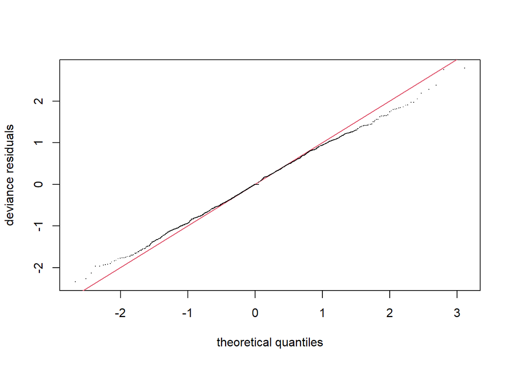

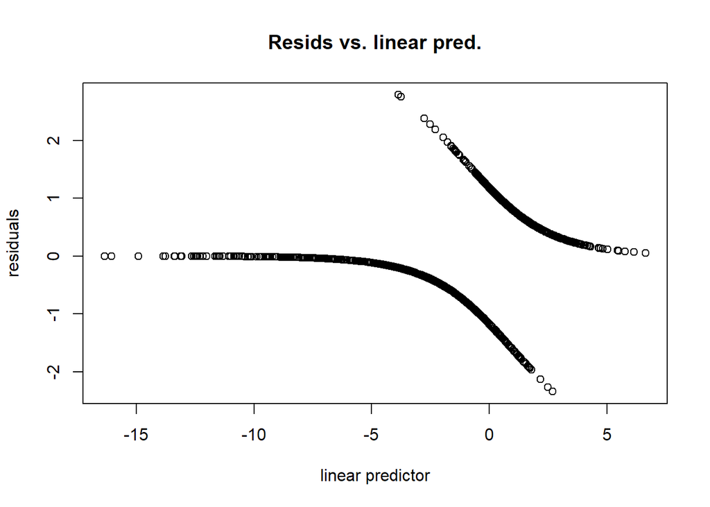

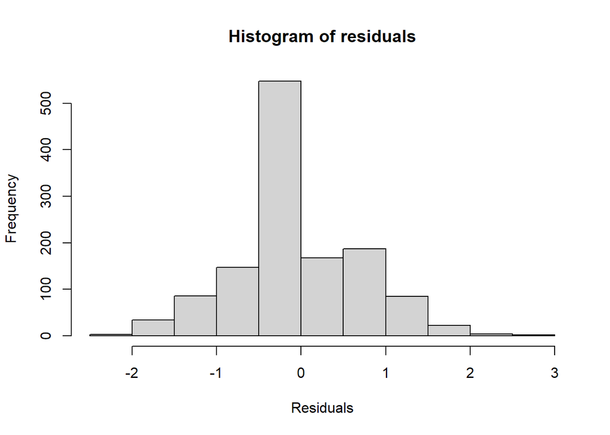

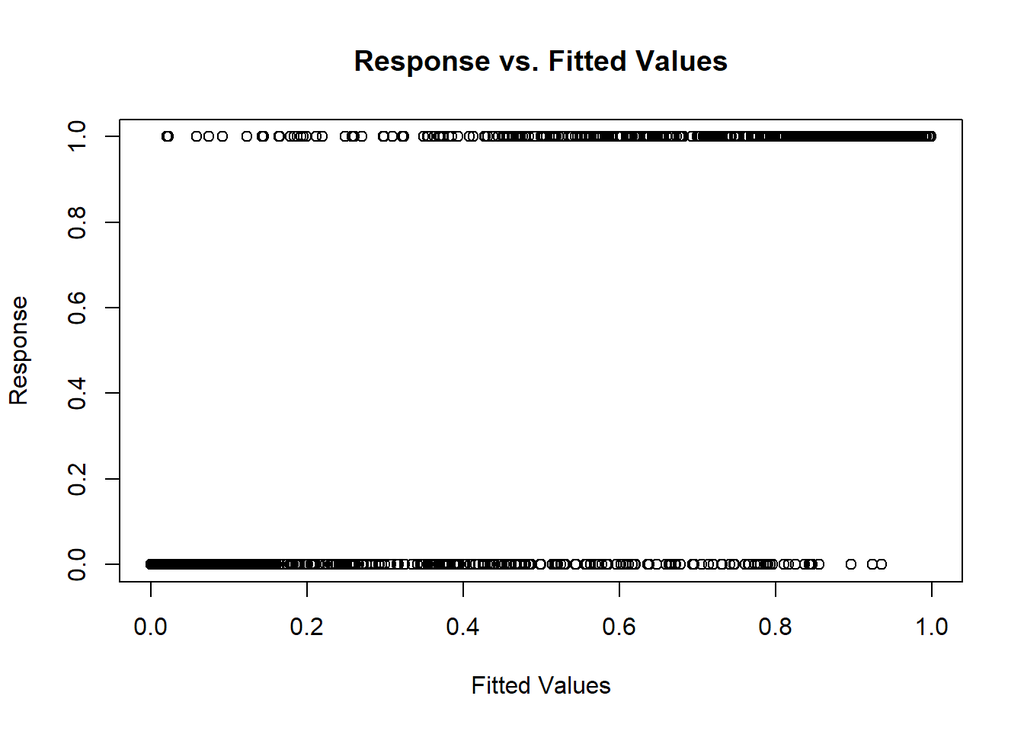

```
##
## Method: REML   Optimizer: outer newton
## full convergence after 6 iterations.
## Gradient range [-1.306115e-08,7.620287e-10]
## (score 494.2641 & scale 1).
## Hessian positive definite, eigenvalue range [0.6648064,17.59944].
## Model rank =  132 / 132
##
## Basis dimension (k) checking results. Low p-value (k-index<1) may
## indicate that k is too low, especially if edf is close to k'.
##
##                            k'   edf k-index p-value
## s(doy):orientationNorth  9.00  4.53       1    0.35
## s(doy):orientationEast   9.00  3.86       1    0.40
## s(doy):orientationSouth  9.00  3.87       1    0.45
## s(doy):orientationWest   9.00  5.18       1    0.42
## s(box.num)              90.00 71.12      NA      NA
```

```r
summary(GAM_TRES2)
```

```
##
## Family: binomial
## Link function: logit
##
## Formula:
## status2 ~ s(doy, by = orientation, k = -1) + orientation + locality +
##     s(box.num, bs = "re")
##
## Parametric coefficients:
##                  Estimate Std. Error z value Pr(>|z|)
## (Intercept)       -2.4433     0.7848  -3.113  0.00185 **
## orientationEast    0.6924     0.9415   0.735  0.46207
## orientationSouth  -0.7951     0.9902  -0.803  0.42199
## orientationWest   -0.6275     1.1030  -0.569  0.56944
## localityDairy      0.8999     0.6800   1.323  0.18572
## localityRailroad   1.1805     0.7464   1.582  0.11374
## ---
## Signif. codes:  0 '***' 0.001 '**' 0.01 '*' 0.05 '.' 0.1 ' ' 1
##
## Approximate significance of smooth terms:
##                            edf Ref.df Chi.sq  p-value
## s(doy):orientationNorth  4.533  5.523  40.71 2.22e-06 ***
## s(doy):orientationEast   3.864  4.802  53.40  < 2e-16 ***
## s(doy):orientationSouth  3.869  4.822  38.06 1.75e-06 ***
## s(doy):orientationWest   5.179  6.223  47.54  < 2e-16 ***
## s(box.num)              71.121 84.000 272.33  < 2e-16 ***
## ---
## Signif. codes:  0 '***' 0.001 '**' 0.01 '*' 0.05 '.' 0.1 ' ' 1
##
## R-sq.(adj) =  0.605   Deviance explained = 58.6%
## -REML = 494.26  Scale est. = 1         n = 1286
```

```r
anova(GAM_TRES, GAM_TRES2, test = "Chisq")
```

```
## Analysis of Deviance Table
##
## Model 1: status2 ~ s(doy, k = -1)
## Model 2: status2 ~ s(doy, by = orientation, k = -1) + orientation + locality +
##     s(box.num, bs = "re")
##   Resid. Df Resid. Dev     Df Deviance  Pr(>Chi)
## 1    1277.8     1311.7
## 2    1174.8      699.2 102.97   612.49 < 2.2e-16 ***
## ---
## Signif. codes:  0 '***' 0.001 '**' 0.01 '*' 0.05 '.' 0.1 ' ' 1
```

## Figure 1

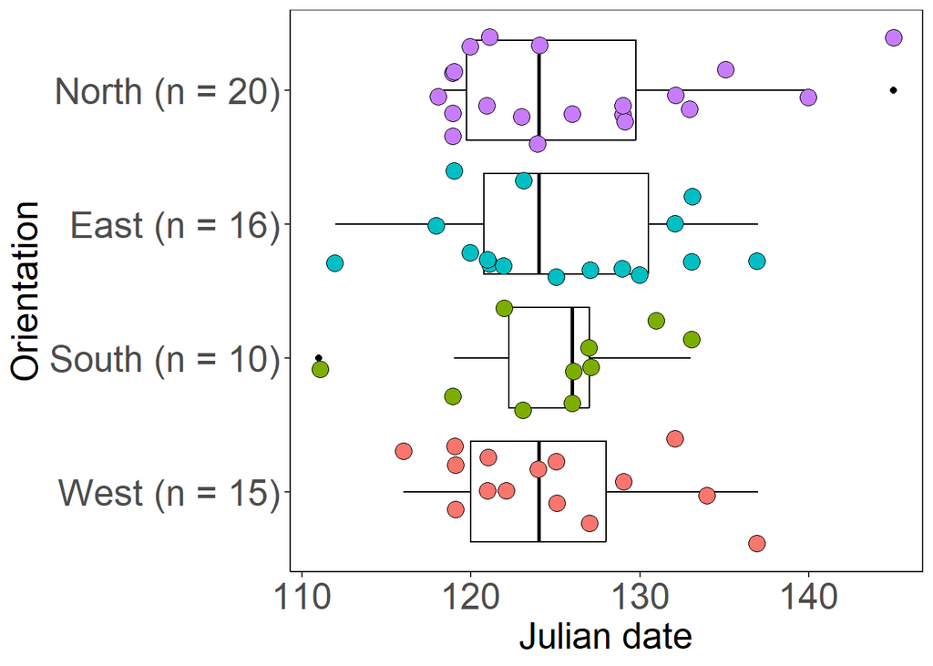

```r
first.egg <- read.csv("../Data/firstegg.csv")
first.egg$First.egg <- as.Date(first.egg$First.egg)
first.egg$doy <- yday(first.egg$First.egg)
first.egg$Orientation <- as.factor(first.egg$Orientation)
first.egg$Orientation <- factor(first.egg$Orientation, levels = c("West", "South", "East", "North"))
boxploteggs <- ggplot(data = first.egg, aes(x = doy, y = Orientation)) +
  geom_boxplot(fill = NA, color = "black") +
  geom_jitter(aes(fill = Orientation), shape = 21, size = 4, width = 0.1) +
  xlab("Julian date") +
  scale_y_discrete(labels = c(
    "West (n = 15)",
    "South (n = 10)",
    "East (n = 16)",
    "North (n = 20)"
  )) +
  theme_bw() +
  theme(axis.title = element_text(size = 20),
        axis.text = element_text(size = 20),
        panel.grid = element_blank(),
        axis.line = element_line(),
        axis.text.x = element_text(angle = 0, hjust = 0.5),
        legend.position = "none") +
  guides(fill = guide_legend(reverse = TRUE))
print(boxploteggs)
```

```r
graph2ppt(file="../Figures/Figure1.pptx", width=8, height=6)
```

# ANALYSIS 2: Clutch size and orientation

## Objective

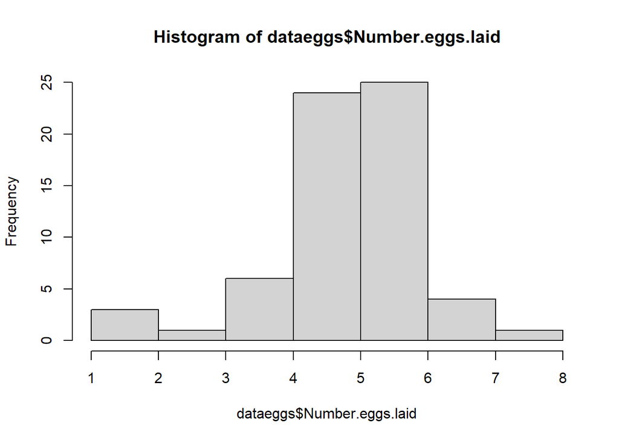

```r
dataeggs <- read.csv("../Data/dataeggs.csv")
hist(dataeggs$Number.eggs.laid)
```

```r
dataeggs$Percentage.eggs.hatched <- as.numeric(dataeggs$Percentage.eggs.hatched)
dataeggs$First.egg <- mdy(dataeggs$First.egg)
dataeggs$julianfegg <- yday(dataeggs$First.egg)
dataeggs$Location <- as.factor(dataeggs$Location)
dataeggs$Box.number <- as.factor(dataeggs$Box.number)
dataeggs$Orientation <- as.factor(dataeggs$Orientation)
dataeggs$julian_z <- scale(dataeggs$julianfegg)
dataeggs$Orientation <- factor(dataeggs$Orientation, levels = c("North", "East", "South", "West"))
```

## Linear models and possible GLMMS

This is a linear Model comparing the number of eggs laid within the four orientations. We also ran a Generalized Linear Mixed Model including fixed effects as Julian date and random effects as location. We set first “Orientation” as unordered categorical variable since compass directions are categories not rankings. North facing boxes are fixed as the reference because our hypothesis focus on south and east boxes.

```r
dataeggs$Orientation <- factor(dataeggs$Orientation, ordered = FALSE)
dataeggs$Orientation <- relevel(dataeggs$Orientation, ref = "North")
numbeggs <- lm(Number.eggs.laid~Orientation, data = dataeggs)
numbeggs2 <- lm(Number.eggs.laid~Orientation+julian_z, data = dataeggs)
numbeggs3 <- lm(Number.eggs.laid~Orientation+julian_z+Location, data = dataeggs)
glmmnumbegg <- lmer(Number.eggs.laid~Orientation+julian_z+(1|Location), data = dataeggs)
```

## Evaluating model’s AIC and ANOVAs

```r
AIC(numbeggs,numbeggs2,numbeggs3,glmmnumbegg)
```

```
##             df      AIC
## numbeggs     5 207.0938
## numbeggs2    6 198.9693
## numbeggs3    8 198.4910
## glmmnumbegg  7 205.8187
```

```r
anova(numbeggs,numbeggs2)
```

```
## Analysis of Variance Table
##
## Model 1: Number.eggs.laid ~ Orientation
## Model 2: Number.eggs.laid ~ Orientation + julian_z
##   Res.Df    RSS Df Sum of Sq      F   Pr(>F)
## 1     60 81.499
## 2     59 69.575  1    11.925 10.112 0.002347 **
## ---
## Signif. codes:  0 '***' 0.001 '**' 0.01 '*' 0.05 '.' 0.1 ' ' 1
```

```r
anova(numbeggs2,numbeggs3)
```

```
## Analysis of Variance Table
##
## Model 1: Number.eggs.laid ~ Orientation + julian_z
## Model 2: Number.eggs.laid ~ Orientation + julian_z + Location
##   Res.Df    RSS Df Sum of Sq      F Pr(>F)
## 1     59 69.575
## 2     57 64.873  2     4.702 2.0657 0.1361
```

## Summary and interpretation

The linear model indicates that south-facing nest boxes had significantly smaller clutch sizes than north-facing boxes after accounting for the effect of Julian date. Clutch sizes in east- and west-facing boxes does not differ significantly from those in north-facing boxes.

```r
summary(numbeggs2)
```

```
##
## Call:
## lm(formula = Number.eggs.laid ~ Orientation + julian_z, data = dataeggs)
##
## Residuals:
##     Min      1Q  Median      3Q     Max
## -3.2972 -0.7466  0.1697  0.7131  1.9751
##
## Coefficients:
##                  Estimate Std. Error t value Pr(>|t|)
## (Intercept)        5.6895     0.2428  23.429  < 2e-16 ***
## OrientationEast   -0.3205     0.3584  -0.894  0.37474
## OrientationSouth  -1.3692     0.4080  -3.356  0.00139 **
## OrientationWest   -0.4136     0.3644  -1.135  0.26098
## julian_z          -0.4363     0.1372  -3.180  0.00235 **
## ---
## Signif. codes:  0 '***' 0.001 '**' 0.01 '*' 0.05 '.' 0.1 ' ' 1
##
## Residual standard error: 1.086 on 59 degrees of freedom
## Multiple R-squared:  0.2789, Adjusted R-squared:   0.23
## F-statistic: 5.705 on 4 and 59 DF,  p-value: 0.0005969
```

## Residuals and homogeneity

Model assumptions are evaluated by examining the normality of residuals and homogeneity of variance.

```r
#GLM
resids<- residuals(numbeggs2)
shapiro.test(resids)
```

```
##
##  Shapiro-Wilk normality test
##
## data:  resids
## W = 0.97508, p-value = 0.2211
```

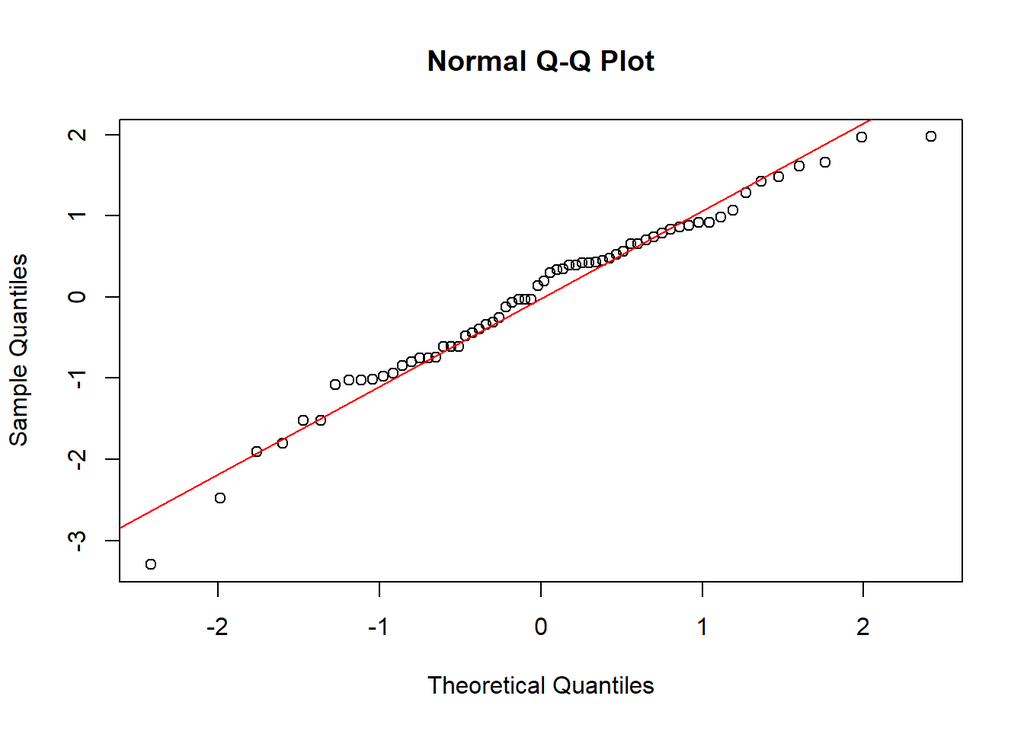

```r
qqnorm(resids)
qqline(resids, col = "red")
```

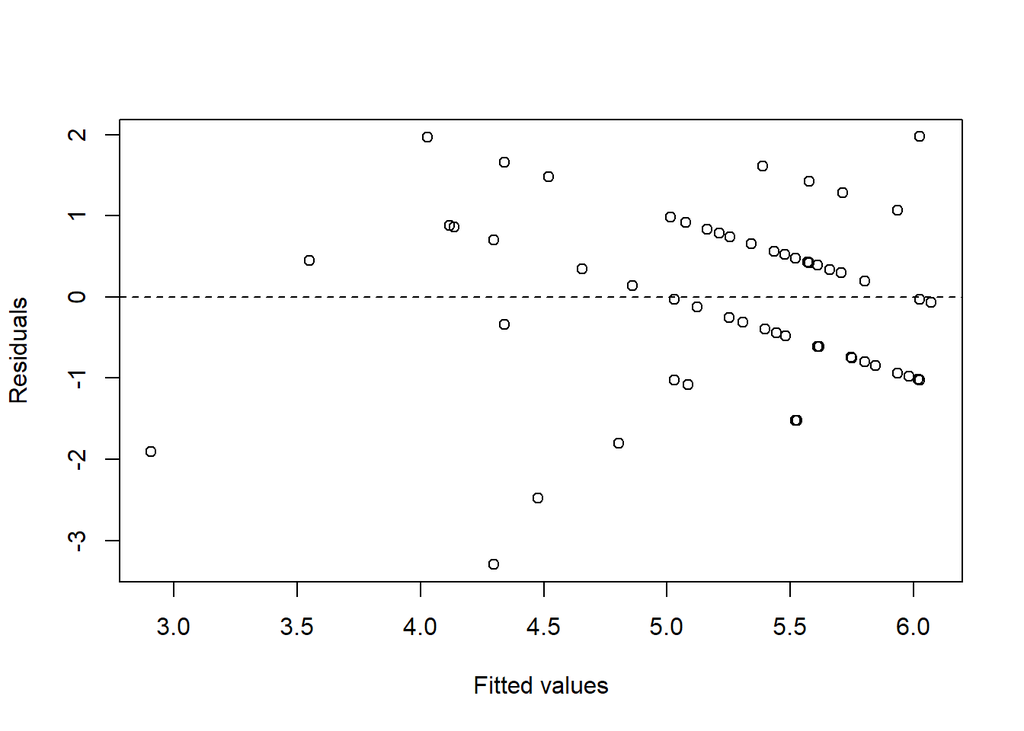

```r
plot(fitted(numbeggs2),
     residuals(numbeggs2),
     xlab = "Fitted values",
     ylab = "Residuals")
abline(h = 0, lty = 2)
```

## Figure 2

Number of eggs laid in nest boxes facing each cardinal direction. Each point represents an individual nest box, while box-and-whisker plots summarize the distribution of clutch sizes within each orientation. Nest boxes showing clear evidence of predation were excluded from the analysis. For example, although 20 north-facing boxes initially contained at least one egg, three were predated and were therefore excluded.

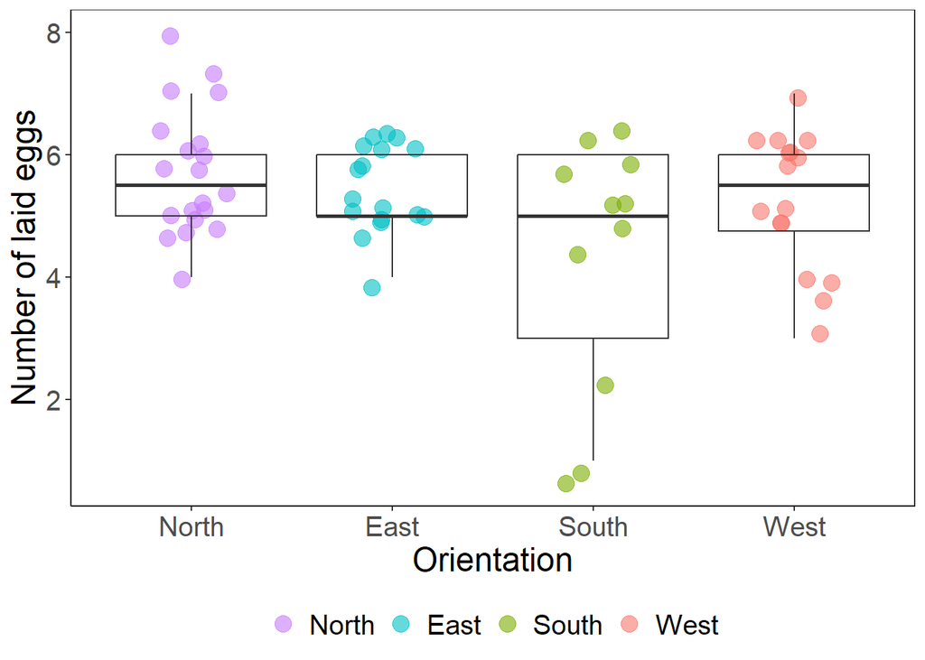

```r
ploteggsnum <- ggplot(data = dataeggs, aes(x = Orientation, y = Number.eggs.laid)) +
  geom_jitter(aes(color = Orientation), size = 4, alpha = 0.6, width = 0.2) +
  geom_boxplot(outlier.colour = "blue", alpha=0) +  # Make boxplot translucent
  ylab("Number of laid eggs") +
  xlab("Orientation") +
  scale_color_manual(values=c("North" = "#C77CFF",
                              "East" = "#00BFC4",
                              "South" = "#7CAE00",
                              "West" = "#F8766D")) +
  theme_bw() +
  theme(
    axis.title = element_text(size = 18),
    axis.text = element_text(size = 15),
    panel.grid = element_blank(),
    axis.line = element_line(),
    axis.text.x = element_text(),
    legend.position = "bottom",
    legend.title = element_blank(),
    legend.text = element_text(size = 15),
    legend.background = element_blank(),
    legend.key = element_rect(fill = "white", color = "white")
  )
print(ploteggsnum)
```

```r
graph2ppt(file="../Figures/Figure2.pptx", width=8, height=6)
```

# ANALYSIS 3: Hatching success and orientation

## Objective

This model tests whether hatching success is associated with nest-box orientation. Hatching success is treated as a binary response, where a nest box is considered successful if at least one egg hatched and the chick was alive during nest checks. Nest boxes that were predated during the egg stage were excluded from this analysis.

## Filtering database

Filtering the database to obtain hatching success.

```r
dataeggs %>%
  filter(Predated_as_eggs=="0") -> hat.succ
```

## Model set ups for hatching success

A binomial liner model of hatching success and orientation. Hatching success is defined as a binomial variable. Comparative models also include Julian day of the first egg laid and Location. Location is also considered as a random effect in a GLMMM

```r
hatch1 <- glm(Hatched ~ Orientation, family = binomial, data = hat.succ)
hatch2 <- glm(Hatched ~ Orientation + julian_z, family = binomial, data=hat.succ)
hatch3 <- glm(Hatched ~ Orientation + julian_z + Location, family = binomial, data = hat.succ)
hatchmodel_glmm <- glmer(Hatched ~ Orientation + julian_z + (1 | Location),family = binomial, data = hat.succ)
```

## Model comparison with ANOVAS and AIC values

Candidate models are compared using Akaike’s Information Criterion (AIC) and likelihood ratio tests (ANOVAs) to identify the most parsimonious model. The model including nest-box orientation and Julian date has the lowest AIC and is selected as the final model. Adding Location did not improve model fit neither is consider a significant random effect.

```r
AIC(hatchmodel_glmm,hatch1,hatch2,hatch3)
```

```
##                 df      AIC
## hatchmodel_glmm  6 69.74522
## hatch1           4 70.17755
## hatch2           5 67.74522
## hatch3           7 69.91825
```

```r
anova(hatch1,hatch2)
```

```
## Analysis of Deviance Table
##
## Model 1: Hatched ~ Orientation
## Model 2: Hatched ~ Orientation + julian_z
##   Resid. Df Resid. Dev Df Deviance Pr(>Chi)
## 1        48     62.178
## 2        47     57.745  1   4.4323  0.03526 *
## ---
## Signif. codes:  0 '***' 0.001 '**' 0.01 '*' 0.05 '.' 0.1 ' ' 1
```

```r
anova(hatch2,hatch3)
```

```
## Analysis of Deviance Table
##
## Model 1: Hatched ~ Orientation + julian_z
## Model 2: Hatched ~ Orientation + julian_z + Location
##   Resid. Df Resid. Dev Df Deviance Pr(>Chi)
## 1        47     57.745
## 2        45     55.918  2    1.827   0.4011
```

```r
anova(hatch1,hatch3)
```

```
## Analysis of Deviance Table
##
## Model 1: Hatched ~ Orientation
## Model 2: Hatched ~ Orientation + julian_z + Location
##   Resid. Df Resid. Dev Df Deviance Pr(>Chi)
## 1        48     62.178
## 2        45     55.918  3   6.2593  0.09965 .
## ---
## Signif. codes:  0 '***' 0.001 '**' 0.01 '*' 0.05 '.' 0.1 ' ' 1
```

## Summary and interpretation

Relative to north-facing boxes, south-facing boxes show the lowest probability of hatching success. Of the eight south-facing nest boxes, only one produced hatchlings, whereas seven failed before hatching. East- and west-facing boxes do not differ significantly from north-facing boxes. Boxes that have a later Julian day of the first egg laid have also a lower probability of hatching. Although the coefficient for Julian day is only marginally significant in the model summary.

```r
summary(hatch2)
```

```
##
## Call:
## glm(formula = Hatched ~ Orientation + julian_z, family = binomial,
##     data = hat.succ)
##
## Coefficients:
##                  Estimate Std. Error z value Pr(>|z|)
## (Intercept)        0.5753     0.5332   1.079   0.2805
## OrientationEast    0.3802     0.8345   0.456   0.6487
## OrientationSouth  -2.7974     1.2468  -2.244   0.0248 *
## OrientationWest   -0.3918     0.7987  -0.491   0.6237
## julian_z          -0.8411     0.4373  -1.923   0.0545 .
## ---
## Signif. codes:  0 '***' 0.001 '**' 0.01 '*' 0.05 '.' 0.1 ' ' 1
##
## (Dispersion parameter for binomial family taken to be 1)
##
##     Null deviance: 70.852  on 51  degrees of freedom
## Residual deviance: 57.745  on 47  degrees of freedom
## AIC: 67.745
##
## Number of Fisher Scoring iterations: 5
```

## Model residuals-Analysis 3

Model assumptions are evaluated using simulated residuals from the DHARMa package. The QQ plot follows the expected distribution, and diagnostic tests show no evidence of non-uniformity, overdispersion, or outliers.

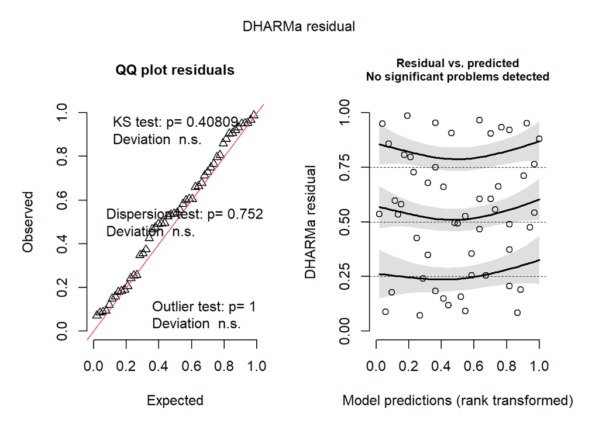

```r
sim <- simulateResiduals(hatch2)
plot(sim)
```

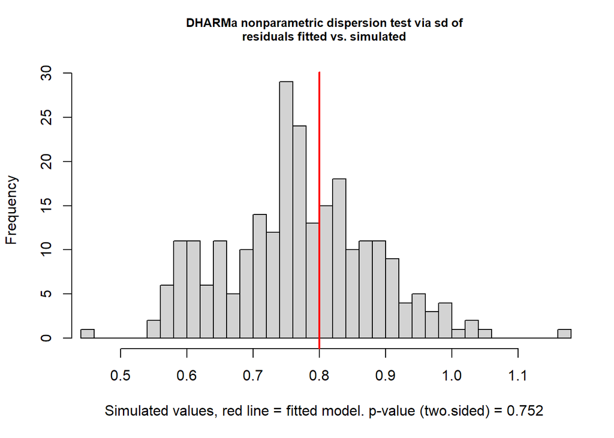

```
##
##  DHARMa nonparametric dispersion test via sd of residuals fitted vs. simulated
##
## data:  simulationOutput
## dispersion = 1.041, p-value = 0.752
## alternative hypothesis: two.sided
```

```r
testDispersion(sim)
```

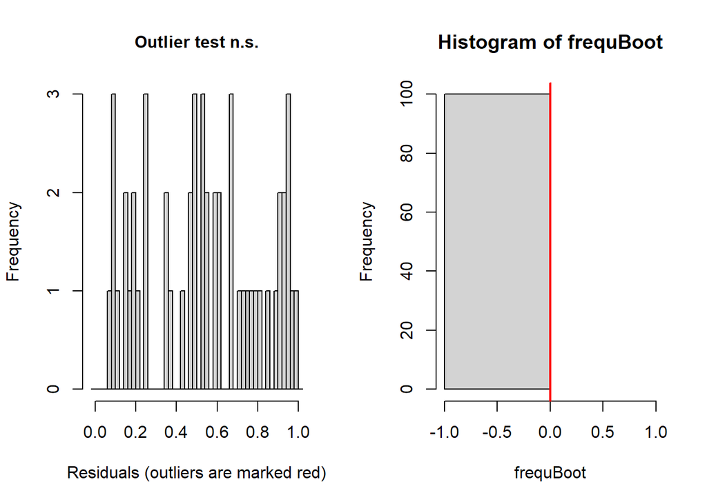

```
##
##  DHARMa bootstrapped outlier test
##
## data:  sim
## outliers at both margin(s) = 0, observations = 52, p-value = 1
## alternative hypothesis: two.sided
##  percent confidence interval:
##  0 0
## sample estimates:
## outlier frequency (expected: 0 )
##                                0
```

```r
testOutliers(sim)
```

## Figure 3

Nest outcomes across the four nest-box entrance orientations. Nest boxes were classified as hatched (dark shade) when at least one egg hatched. Failed nests (medium shade) were those in which eggs were laid but failed to hatch, while the adults retained the nest box. Unoccupied boxes (light shade) included nest boxes that were never occupied during the breeding season or were abandoned following a predation event.

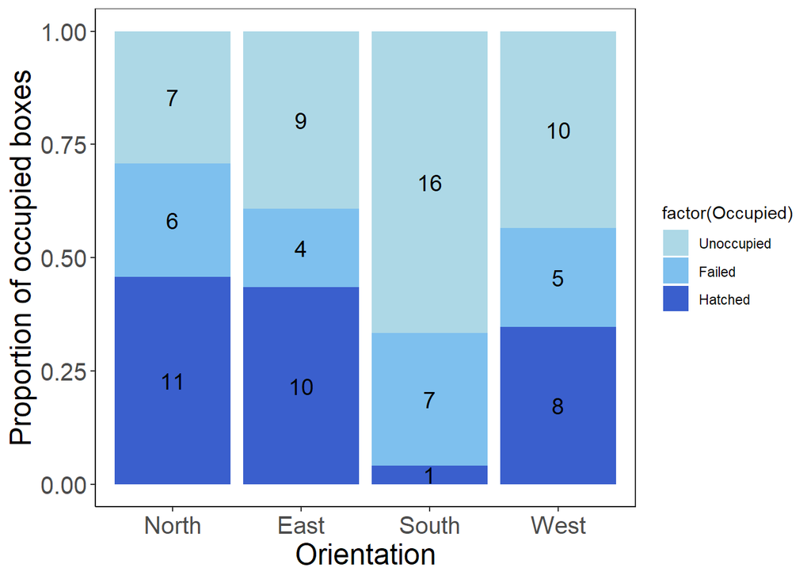

```r
summhatsucc <- read.csv("../Data/summhatchsucc.csv")
summhatsucc$Orientation <- factor(summhatsucc$Orientation, levels = c("North", "East", "South", "West"))

hatchedplotfull <- ggplot(summhatsucc, aes(x = Orientation, y = prop, fill = factor(Occupied))) +
  geom_bar(stat = "identity", position = "fill") +
  ylab("Proportion of occupied boxes") +
  xlab("Orientation") +
  theme_bw() +
  theme(
    axis.title = element_text(size = 18),
    axis.text = element_text(size = 15),
    panel.grid = element_blank(),
    axis.line = element_line(),
    axis.text.x = element_text()
  ) +
  # Adding percentage labels inside bars
  geom_text(aes(label = n),
            position = position_stack(vjust = 0.5), size = 5) +
  scale_fill_manual(values = c("lightblue","skyblue2", "royalblue3"), labels = c("Unoccupied","Failed", "Hatched"))
print(hatchedplotfull)
```

```r
graph2ppt(file="../Figures/Figure3.pptx", width=8, height=6)
```